# London Fire Service Statistical Summary

# Performing Two Sample T-Test

```r
t_test<-t.test(
    response_time~IncGeo_BoroughName,
    data=fire_data.E.G
)

print(t_test)
```

```
##
##  Welch Two Sample t-test
##
## data:  response_time by IncGeo_BoroughName
## t = 2.8542, df = 19303, p-value = 0.00432
## alternative hypothesis: true difference in means between group EALING and group GREENWICH is not equal to 0
## 95 percent confidence interval:
##  1.739777 9.368041
## sample estimates:
##    mean in group EALING mean in group GREENWICH
##                316.9342                311.3803
```

# Estimation

```r
m.rt.by.IncGeo_BoroughName <- lm(response_time~IncGeo_BoroughName, data=fire_data.E.G)
(  m.rt.by.IncGeo_BoroughName.emm <- emmeans(m.rt.by.IncGeo_BoroughName, ~IncGeo_BoroughName)  )
```

```
##  IncGeo_BoroughName emmean   SE    df lower.CL upper.CL
##  EALING                317 1.34 19445      314      320
##  GREENWICH             311 1.42 19445      309      314
##
## Confidence level used: 0.95
```

```r
(  m.rt.by.IncGeo_BoroughName.contrast <- confint(pairs(m.rt.by.IncGeo_BoroughName.emm))  )
```

```
##  contrast           estimate   SE    df lower.CL upper.CL
##  EALING - GREENWICH     5.55 1.95 19445     1.73     9.38
##
## Confidence level used: 0.95
```

# Side-by-side plots CIs for the estimates for each group as well as the CI for the difference between groups

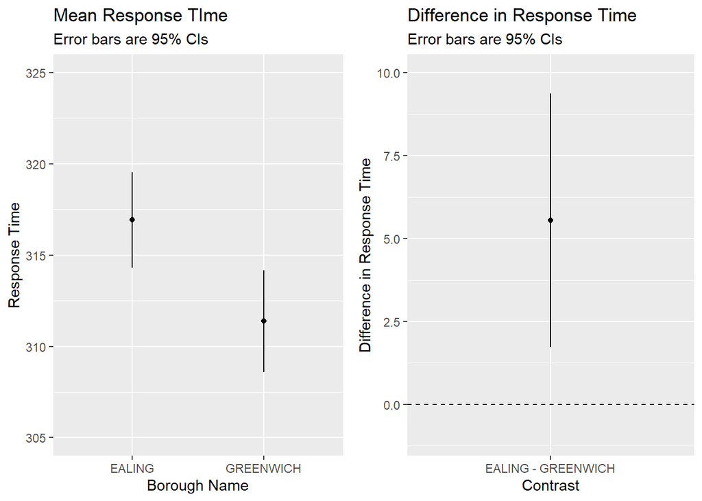

```r
grid.arrange(
    ggplot(summary(m.rt.by.IncGeo_BoroughName.emm), aes(x=IncGeo_BoroughName, y=emmean, ymin=lower.CL, ymax=upper.CL)) +
        geom_point() + geom_linerange() +
        labs(y="Response Time", x="Borough Name", subtitle="Error bars are 95% CIs", title="Mean Response TIme") + ylim(305,325),
    ggplot(m.rt.by.IncGeo_BoroughName.contrast, aes(x=contrast, y=estimate, ymin=lower.CL, ymax=upper.CL)) +
        geom_point() + geom_linerange() +
        labs(y="Difference in Response Time", x="Contrast", subtitle="Error bars are 95% CIs", title="Difference in Response Time") + ylim(-1,10) +
        geom_hline(yintercept=0, lty=2),
    ncol=2
)
```

# Section 2

This report presents the results of the analyses requested by the board.This used the data provided is London_Fire_data with almost 322375 incidents and 39 different variables. There was a small amount of missing data or inaccurate data entry the data was being replaced by zero or removed.

# 1) The costs of responding to fires and false alarms:

Total cost associated with all indecents including Fires, False and Speacial Services : 151121790GBP  
Total Cost associated with actual Fires : 43059576 GBP  
Total Cost associated with False Alarms : 61249812 GBP  
Average cost spent on actual Fires : 837.9795 GBP  
Average Cost Spent on False Alarms : 378.3796 GBP  
Cost spent on False Fire Alarm is high as we get a lot of False Alarms counting to 162299

```
## # A tibble: 3 × 4
##   IncidentGroup   total_cost mean_cost Number_of_Alarms
##   <chr>                <dbl>     <dbl>            <int>
## 1 False Alarm       61249812      378.           162299
## 2 Fire              43059576      838.            51443
## 3 Special Service   46812402      437.           108633
```

# 2) The distribution of response times

Overall Response time of all indecents including Fires, False and Speacial Services : 308.0578 sec  
The Mean Response time for actual Fires : 319.4506 seconds  
The Mean Response time for False Alarm : 298.9196 seconds  
The Mean Response time for Special Services : 317.8027 seconds  
The Graph depicts the Distribution of Response time for different Incidents and the black line indicates the mean value of overall Response time.

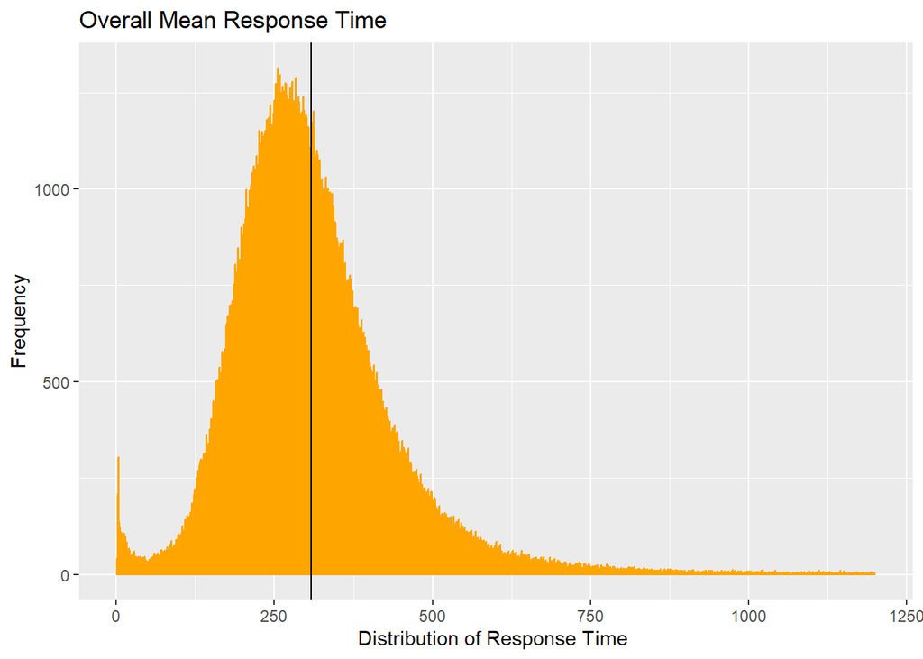

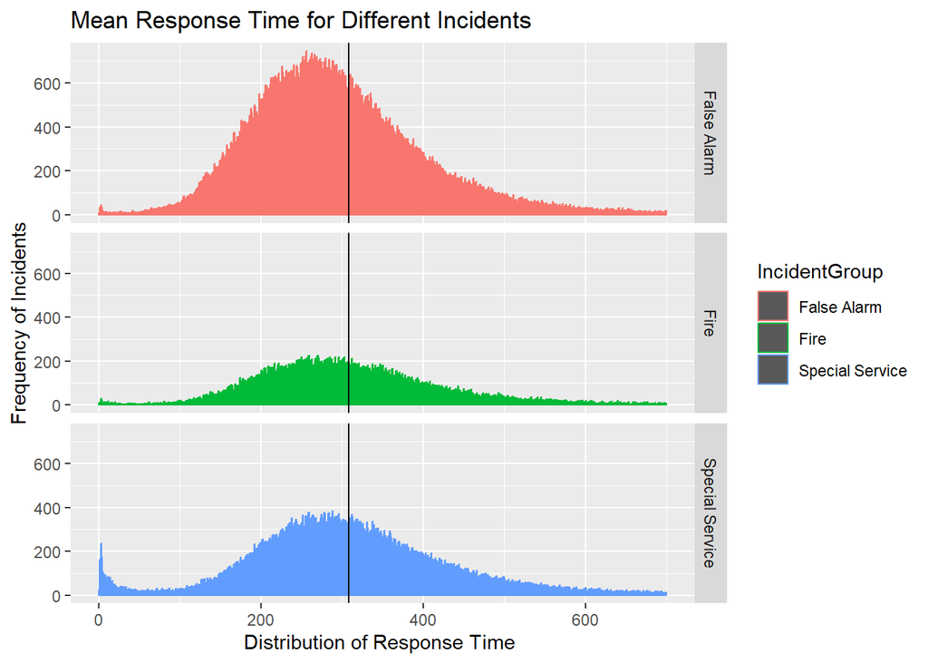

```
## # A tibble: 3 × 3
##   IncidentGroup    mean Frequency
##   <chr>           <dbl>     <int>
## 1 False Alarm      299.    160995
## 2 Fire             319.     50921
## 3 Special Service  318.     91440
```

Inference from Average Response time:

Avg Response time of Fires > Avg Response time of Special Services > Avg Response time of False Alarm  
The Response time for Fires and Special Services does not vary much than that to False Alarm

# 3) Summary of special service response times

The count,mean response time ,10th percentile and 90th percentile for each type of incidents is summarized in table below for Special Services:

```
## # A tibble: 20 × 5
##    SpecialServiceType              Frequency Mean_Response_Time Quantile10 Quantile90
##    <chr>                               <int>              <dbl>      <dbl>      <dbl>
##  1 Advice Only                          1817               320.       188        462.
##  2 Animal assistance incidents          2157               341.       190        517.
##  3 Assist other agencies                4339               317.       182        462
##  4 Effecting entry/exit                23300               317.       182        470
##  5 Evacuation (no fire)                  656               327.       192.       474.
##  6 Flooding                            20428               328.       191        485
##  7 Hazardous Materials incident         2518               316.       185        463.
##  8 Lift Release                         4506               307.       178        450
##  9 Making Safe (not RTC)                3344               321.       177        494
## 10 Medical Incident                     2080               222.         8        433
## 11 No action (not false alarm)          7572               328.       188        485
## 12 Other rescue/release of persons      1196               331.       190.       482
## 13 Other Transport incident              858               318.       151.       491
## 14 Removal of objects from people       1526               208.         7        456
## 15 Rescue or evacuation from water       160               324.       176.       484.
## 16 RTC                                 12077               318.       157        500
## 17 Spills and Leaks (not RTC)           2043               350.       195.       530
## 18 Stand By                              154               309.       165.       472.
## 19 Suicide/attempts                      707               323.       181        482
## 20 Water provision                         1               245        245        245
```

# 4) A t-test comparing Ealing and Greenwich

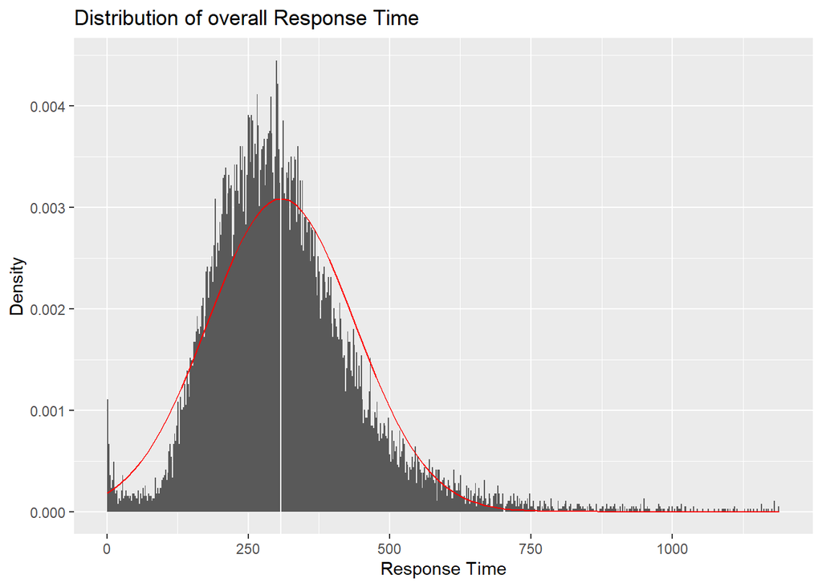

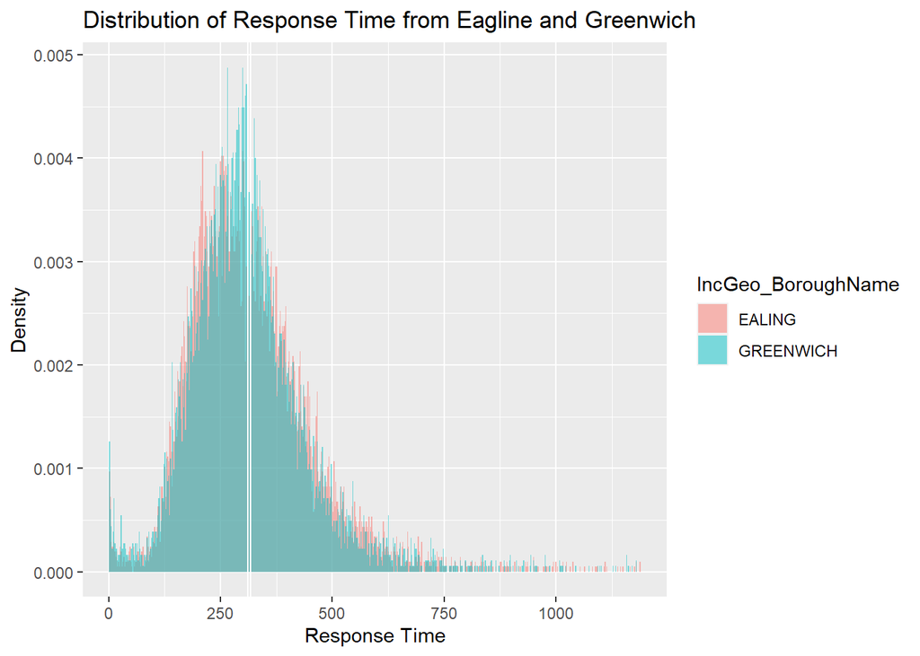

```
##
##  Welch Two Sample t-test
##
## data:  response_time by IncGeo_BoroughName
## t = 2.8542, df = 19303, p-value = 0.00432
## alternative hypothesis: true difference in means between group EALING and group GREENWICH is not equal to 0
## 95 percent confidence interval:
##  1.739777 9.368041
## sample estimates:
##    mean in group EALING mean in group GREENWICH
##                316.9342                311.3803
```

The Two Sample t-test analysis shows that the Ealing’s mean response time of 316.93 seconds is significantly higher than the Greenwhich average response time 311.38 Seconds , welch t(19303) = 2.85, p=0.00432 with a difference of 5.55 seconds

# Estimation:

```
##  IncGeo_BoroughName emmean   SE    df lower.CL upper.CL
##  EALING                317 1.34 19445      314      320
##  GREENWICH             311 1.42 19445      309      314
##
## Confidence level used: 0.95
```

```
##  contrast           estimate   SE    df lower.CL upper.CL
##  EALING - GREENWICH     5.55 1.95 19445     1.73     9.38
##
## Confidence level used: 0.95
```

The mean response time for Ealing is 317 seconds 95% CI [314–320]. The mean response time for Greenwich is 311 seconds 95% CI [309–314]. The gain is 5.55 seconds 95% CI [1.73–9.38] smaller at Greenwich compared to Ealing.  
Below image well describes the CI:

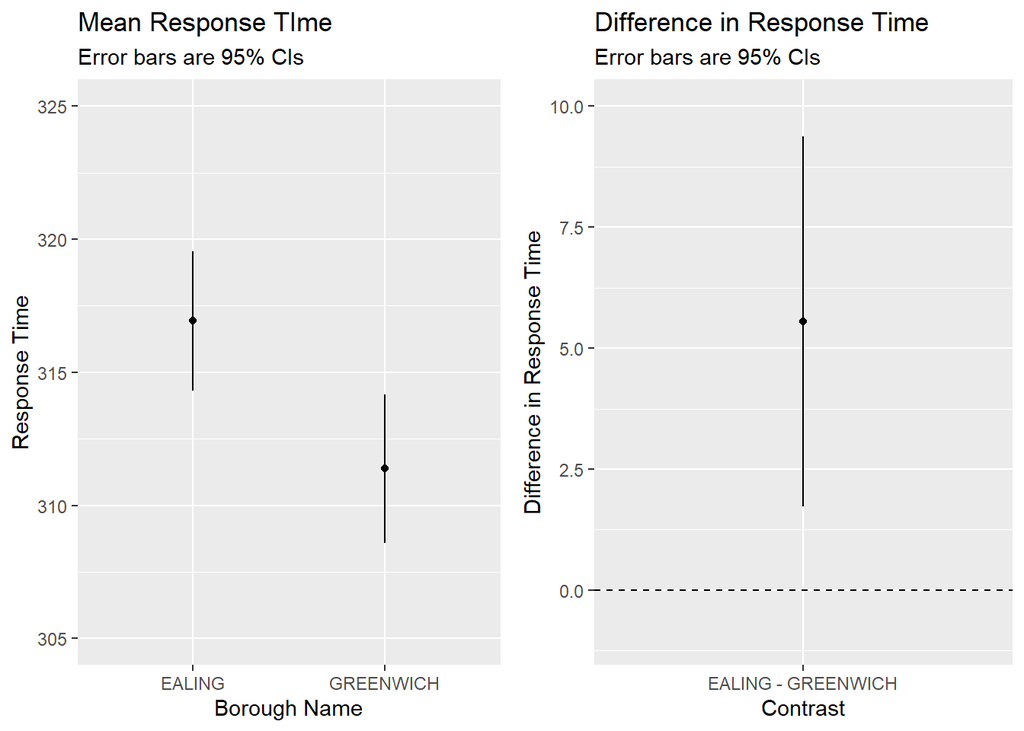